# NZ GREEN Grid Household Electricity Demand Data

EECA Data Analysis (Part C) Upscaling Advice Report v0.975

Ben Anderson

Last run at: 2019-11-06 09:29:11 (Pacific/Auckland)

# 1 About

## 1.1 Citation

If you wish to use any of the material from this report please cite as:

- Ben Anderson (2019) *NZ GREEN Grid Household Electricity Demand Data: EECA Data Analysis (Part C) Upscaling Advice Report v0.975*, [Centre for Sustainability](http://www.otago.ac.nz/centre-sustainability/), University of Otago: Dunedin.

This work is (c) 2019 the authors. Usage right are specified in the License section (1.4).

## 1.2 Report circulation

- Public – this report is intended for publication following EECA approval.

## 1.3 Code

All code used to create this report is available from:

- https://github.com/CfSOtago/GREENGridEECA

## 1.4 License

This work is made available under the Creative Commons [Attribution-ShareAlike 4.0 International (CC BY-SA 4.0) License](https://creativecommons.org/licenses/by-sa/4.0/).

This means you are free to:

- *Share* — copy and redistribute the material in any medium or format
- *Adapt* — remix, transform, and build upon the material for any purpose, even commercially.

Under the following terms:

- *Attribution* — You must give appropriate credit, provide a link to the license, and indicate if changes were made. You may do so in any reasonable manner, but not in any way that suggests the licensor endorses you or your use.
- *ShareAlike* — If you remix, transform, or build upon the material, you must distribute your contributions under the same license as the original.
- *No additional restrictions* — You may not apply legal terms or technological measures that legally restrict others from doing anything the license permits.

**Notices:**

- You do not have to comply with the license for elements of the material in the public domain or where your use is permitted by an applicable exception or limitation.
- No warranties are given. The license may not give you all of the permissions necessary for your intended use. For example, other rights such as publicity, privacy, or moral rights may limit how you use the material.

For the avoidance of doubt and explanation of terms please refer to the full [license notice](https://creativecommons.org/licenses/by-sa/4.0/) and [legal code](https://creativecommons.org/licenses/by-sa/4.0/legalcode).

## 1.5 History

You may not be reading the most recent version of this report. Please check:

- the github [R code repository](https://cfsotago.github.io/GREENGridEECA/);
- our [issues list](https://github.com/CfSOtago/GREENGridEECA/issues) for any unfixed problems;
- our [project documentation site](https://cfsotago.github.io/GREENGridEECA/) and specifically;
- this [report’s edit history](https://github.com/CfSOtago/GREENGridEECA/commits/master/reports/partC_upscalingAdvice)

## 1.6 Support

This work was supported by:

- The New Zealand Energy Efficiency and Conservation Authority ([EECA](https://www.eeca.govt.nz/))
- The European Union via [SPATIALEC](http://www.energy.soton.ac.uk/tag/spatialec/), a Marie Skłodowska-Curie [Global Fellowship](https://ec.europa.eu/research/mariecurieactions/actions/individual-fellowships_en) based at the University of Otago’s [Centre for Sustainability](http://www.otago.ac.nz/centre-sustainability/staff/otago673896.html) (2017-2019) & the University of Southampton’s [Sustainable Energy Research Group](http://www.otago.ac.nz/centre-sustainability/staff/otago673896.html) (2019-2020).

# 2 Introduction

[Previous work](https://cfsotago.github.io/GREENGridEECA/) conducted as Part B of this project has calculated the % contribution of different appliances to peak power load (kW) and to overall annual consumption (kWh) for the ~ 40 New Zealand GREEN Grid household electricity demand study dwellings (Stephenson et al. 2017).

EECA have expressed an interest in understanding how these results and/or this sample of dwellings can be scaled up to provide estimates of the same values for the overall New Zealand residential dwelling stock/household population.

Unfortunately, due to their [recruitment method](https://cfsotago.github.io/GREENGridData/overviewReport_v1.0.html#4_study_recruitment) the New Zealand GREEN Grid household electricity demand study sample dwellings are unlikely to be representative of either the two regions from which they were drawn (Taranaki and Hawke’s Bay) or New Zealand as a whole as we discuss below. In addition these households form an extremely small sample so that the resulting confidence intervals and margins of error around derived estimates are large (see Section 3.3 below). In combination, these two issues mean that upscaling the sample to represent either the regions from which they were drawn and/or the national household population will produce estimates that are neither representative nor precise.

If we assume that the GREEN Grid sample adequately represents the regional or national distribution of electricity-using devices and appliances and that the way the occupants of the GREEN Grid dwellings use these devices and appliances represents the usage habits and patterns of all New Zealand households then we could make generalisable inferences. However we can do very little about the lack of precision caused by the small sample size.

Whilst these assumptions may be plausible in the case of, say, lighting, it is likely to be less plausible in the case of space or hot water heating due to the absence of reticulated gas and coal/wood as main energy sources from the GREEN Grid sample. Further, the very small size of the GREEN Grid sample means that unusual patterns may be unrealistically inflated in the upscaling process.

Nevertheless it is still useful to review potential upscaling methods should we wish to make assumptions of this kind or to guide future work when a larger and representative sample of New Zealand households and their energy consumption is available.

The remainder of this report therefore introduces three potential upscaling methods both of which have been used with the GREEN Grid household electricity demand data in different ways and for different purposes. The first is a simple multiplication method used to estimate overall residential electricity consumption for comparison to the GXP level data used in Part B. The second is a simple proportionate upscaling method used to estimate energy demand for heat pumps in New Zealand (Dortans 2019). The third is a more complex re-weighting approach that uses iterative proportional fitting (simpson_combining_2005; Anderson 2012) to re-weight households on multiple dimensions to match known Census distributions (Anderson 2019).

# 3 Data

A number of data sources are used in this report.

## 3.1 Census 2013

This data comprises family, household or dwelling counts (depending on the variables of interest) at area unit level. The data was downloaded from the Stats NZ census table [download tool](http://nzdotstat.stats.govt.nz/wbos/index.aspx) and processed using [code](https://git.soton.ac.uk/ba1e12/spatialec/blob/master/dataProcessing/processCensusAu2013.Rmd) developed as part of the EU H2020 Marie Skłodowska-Curie scheme-funded [SPATIALEC](http://www.energy.soton.ac.uk/tag/spatialec/) Global Fellowship hosted by the University of Otago.

## 3.2 Grid exit point kWh export (GXP)

This data comprises the half-hourly electricity export (kWh) data for each New Zealand Grid Exit Point for [2015](https://cfsotago.github.io/GREENGridEECA/gxpReport_v0.5.html) downloaded from the Electricity Authority EMI [grid export database](https://www.emi.ea.govt.nz/Wholesale/Datasets/Metered_data/Grid_export). We use this data to provide *total* electricity consumption levels against which we can compare our various residential consumption estimates.

## 3.3 NZ GREEN Grid Household Electricity Demand

```
## Date in ISO8601 format; converting timezone from UTC to "Pacific/Auckland".
## Date in ISO8601 format; converting timezone from UTC to "Pacific/Auckland".
```

This sample comprises 44 households who were recruited via the local electricity distribution businesses (EDBs) in two areas: Taranaki starting in May 2014 and Hawkes Bay starting in November 2014 (Anderson and Eyers 2018).

Recruitment was via a non-random sampling method and a number of households were intentionally selected for their ‘complex’ electricity consumption (and embedded generation) patterns and appliances (Giraldo Ocampo 2015; Stephenson et al. 2017; Jack et al. 2018; Suomalainen et al. 2019).

The EDBs invited their own employees and those of other local companies to participate in the research and ~80 interested potential participants completed short or long forms of the Energy Cultures 2 household survey (Wooliscroft 2015). Households were then selected from this pool by the project team based on selection criteria relevant to the GREEN Grid project. These included:

- having the majority of their energy supply from electricity (i.e. not gas heating);
- presence of children;
- family and dwelling size;
- types of appliances owned.

As a result of this process the sample cannot be assumed to represent the population of customers (or employees) of any of the companies involved, nor the populations in each location or New Zealand dwellings as a whole (Stephenson et al. 2017).

### 3.3.1 Annual electricity consumption

Table 3.1 shows the mean annualised net electricity consumption for all dwellings in the data by presence of photovoltaic panel (PV) inverter. For those that do not have PV the mean annual consumption of ~ 8,000 kWh is ~ 14% higher than the ~ 7,000 kWh reported for 2018 (Electricity Authority/Te Mana Hiko 2018). As we discuss below, this is likely to be due to the social composition of these dwelling.

Table 3.1: Summary statistics for annualised net electricity consumption by presence of PV Inverter (NA indicates unknown)

| PV Inverter | min | mean | max | sd | nHouseholds | ci_lower | ci_upper |
| --- | --- | --- | --- | --- | --- | --- | --- |
| NA | 6157.09 | 10329.84 | 14502.59 | 5901.16 | 2 | 2151.40 | 18508.28 |
| No | 2298.76 | 7971.57 | 16762.36 | 3262.85 | 39 | 6947.53 | 8995.60 |
| Yes | -5144.71 | 945.10 | 9423.95 | 6151.52 | 4 | -5083.28 | 6973.48 |

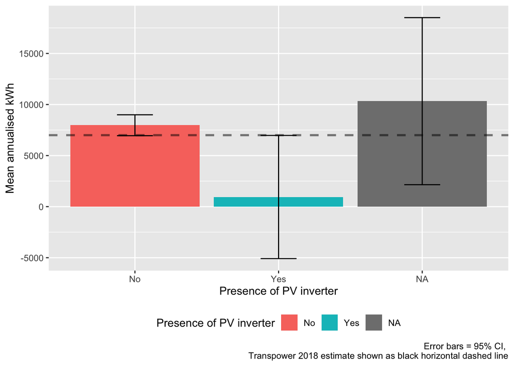

Figure 3.1: Mean annual net electricity consumption by presence of PV inverter

Figure 3.1 plots these values and the width of the 95% confidence intervals illustrates the degree of uncertainty in the mean estimates which is largely driven by the small sample sizes reported in Table 3.1 together with inter-household heterogeneity. It is worth noting however that the ~ 7,000 kWh reported for 2018 (Electricity Authority/Te Mana Hiko 2018) lies just within the lower 95% confidence interval for the dwellings with no PV inverter.

### 3.3.2 Heating

As an example of the sample bias, Table 3.2 shows the main heat source used for space heating in the GREEN Grid sample. As we can see heat pumps were the main heat source in 55% of dwellings and wood burners in 25% with very little use of gas in any form and no record of coal use.

Table 3.2: Main method of heating, n dwellings = 44

| Appliance | N | % |
| --- | --- | --- |
| NA | 0 | 0.00 |
|  | 2 | 4.55 |
| Enclosed wood burner | 11 | 25.00 |
| HRV or other ventilation system | 2 | 4.55 |
| Heat pump | 24 | 54.55 |
| Open fire | 1 | 2.27 |
| Other | 1 | 2.27 |
| Portable electric heaters | 1 | 2.27 |
| Portable gas heater | 1 | 2.27 |
| Underfloor gas heating | 1 | 2.27 |

Table 3.3: Main heat source

| sample | Appliance | % | Lower 95% CI | Upper 95% CI |
| --- | --- | --- | --- | --- |
| GREEN Grid sample | Enclosed wood burner | 25.0 | -0.6 | 50.6 |
| GREEN Grid sample | Heat pump | 54.5 | 34.6 | 74.5 |
| GREEN Grid sample | Portable electric heaters | 2.3 | -26.9 | 31.5 |
| HCS 2015: owner occupied | Heat pump | 40.0 | 33.9 | 46.1 |
| HCS 2015: owner occupied | Enclosed wood burner | 39.0 | 32.9 | 45.1 |
| HCS 2015: owner occupied | Portable electric heaters | 25.0 | 18.9 | 31.1 |
| HCS 2015: owner occupied | Portable gas heater | 4.0 | -2.1 | 10.1 |
| HCS 2015: rental | Heat pump | 25.0 | 14.2 | 35.8 |
| HCS 2015: rental | Enclosed wood burner | 23.0 | 12.2 | 33.8 |
| HCS 2015: rental | Portable electric heaters | 33.0 | 22.2 | 43.8 |
| HCS 2015: rental | Portable gas heater | 15.0 | 4.2 | 25.8 |

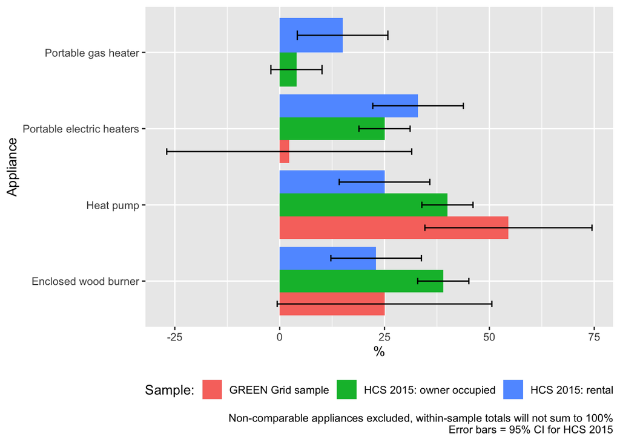

Figure 3.2: Comparison of GREEN Grid and HCS 2015 heating appliance ownership rates

Further, Table 3.4 compares the ‘Fuel type used to heat dwelling’ for Census 2013 and the ‘methods available for heating your house’ in the GREEN Grid sample. Note that multiple responses were possible in both data sources and the responses have been [coded](https://git.soton.ac.uk/ba1e12/spatialec/blob/master/dataProcessing/processGreenGridSurvey.R) to be as comparable as possible.

Table 3.4: Comparing heating fuel used/methods available (% of dwellings)

| Electricity | Gas | Wood | Coal | Other | source |
| --- | --- | --- | --- | --- | --- |
| 50.65 | 17.18 | 23.03 | 2.59 | 6.55 | Census 2013 (all regions) |
| 67.52 | 32.09 | 46.05 | 1.60 | 7.93 | Census 2013 (Taranaki & Hawke’s Bay only) |
| 54.29 | 11.43 | 22.86 | 0.00 | 11.43 | GREEN Grid sample |

Note:  
Row totals may sum to more than 100% due to multiple responses Open fire is coded as ‘Other’ in GREEN Grid - it is not clear how this is coded in the Census data

Table 3.4 shows that the GREEN Grid sample has a similar ‘available fuel’ profile to New Zealand dwellings as a whole but is not representative of the combined regions of Taranaki and Hawke’s Bay from which it was drawn. In particular there are lower rates of Gas and Wood and much higher ‘Other’ although as noted the latter may be a coding artefact.

### 3.3.3 Number of rooms

Table 3.5 shows the distribution of the number of rooms per household and shows that the GREEN Grid sample has fewer smaller dwellings and more larger dwellings than both New Zealand as a whole and the combined regions from which the sample is drawn.

Table 3.5: Comparing number of rooms per dwelling (% of dwellings)

| nRooms1_4 | nRooms5_6 | nRooms7m | source |
| --- | --- | --- | --- |
| 15.63 | 40.23 | 44.13 | Census 2013 (all regions) |
| 12.88 | 42.97 | 44.19 | Census 2013 (Taranaki & Hawke’s Bay only) |
| 7.14 | 42.86 | 50.00 | GREEN Grid sample |

### 3.3.4 Number of people

Table 3.6 shows the distribution of number of people per household and shows that the GREEN Grid sample has far lower proportions of single or 2 person households than either the 2013 Census as a whole or the two regions but a much higher proportion of larger households. Since electricity demand is well known to correlate with the number of occupants (Huebner et al. 2016) we would therefore expect average per dwelling/household GREEN Grid sample demand (or consumption) values to be overestimates of the true national values.

Table 3.6: Comparing number of people per dwelling (% of dwellings)

| nPeople_1 | nPeople_2 | nPeople_3 | nPeople_4m | source |
| --- | --- | --- | --- | --- |
| 22.93 | 34.05 | 16.44 | 26.58 | Census 2013 (all regions) |
| 25.82 | 36.13 | 15.31 | 22.65 | Census 2013 (Taranaki & Hawke’s Bay only) |
| 9.52 | 23.81 | 19.05 | 47.62 | GREEN Grid sample |

### 3.3.5 Number of children

Finally, Table 3.7 shows the distribution of 0 vs 1+ children per household. As expected, the GREEN grid sample has fewer households with no children and far more households with children than the population as a whole and this is also true for the two regions. Again, we would therefore expect average per dwelling/household GREEn Grid sample demand (or consumption) values to be differ substantially from the true values.

Table 3.7: Comparing number of households with 0 vs 1+ child per dwelling (% of dwellings)

| nKids_0 | nKids_1m | source |
| --- | --- | --- |
| 66.04 | 33.96 | Census 2013 (all regions) |
| 53.69 | 46.31 | Census 2013 (Taranaki & Hawke’s Bay only) |
| 30.95 | 69.05 | GREEN Grid sample |

## 3.4 Summary

In summary we conclude that the GREEN Grid sample comprises more larger dwellings with more heat pumps, more occupants and more children than we would expect for the population as a whole and indeed the regions from which they were drawn. As a result we cannot assume the sample to be representative of the New Zealand household population.

# 4 Scaling examples

Despite our concerns over the representativeness of the GREEN Grid sample it is still helpful to use it as a data source to explore a number of scaling approaches. These range from simple multiplication through proportional multiplication to complex re-weighting schemes.

## 4.1 Simple multiplication

Under this method we assume the GREEN Grid sample to be representative and simply multiply an estimated mean (or total) household values derived from the GREEN Grid sample by the relevant national or regional household counts.

### 4.1.1 Total electricity consumption profiles - 2015

As an example let us assume we wish to calculate half-hourly national total residential electricity consumption profiles by season for 2015 to estimate their contribution to overall electricity consumption in New Zealand. To do this, we use the half-hourly total kWh data produced in [Part A](https://cfsotago.github.io/GREENGridEECA/partA_dataProcessingReport_v1.0.html#610_total_load) and calculate mean energy consumption (kWh) per half-hour for each season in 2015.

We do this using all values even where negative as we assume that negative consumption is export to the grid by the few households with photovoltaic panels (see Table 3.1). Clearly we could:

- remove these households although the negative power values are only likely to have an effect during the middle of the day (during off-peak periods) and mainly in summer;
- convert the -ve PV circuit values to +ve demand and re-build the ‘total household load’ estimates to give ‘gross load’ prior to conducting these analyses.

For simplicity and to keep the work within resource scope we have left these approaches for future work.

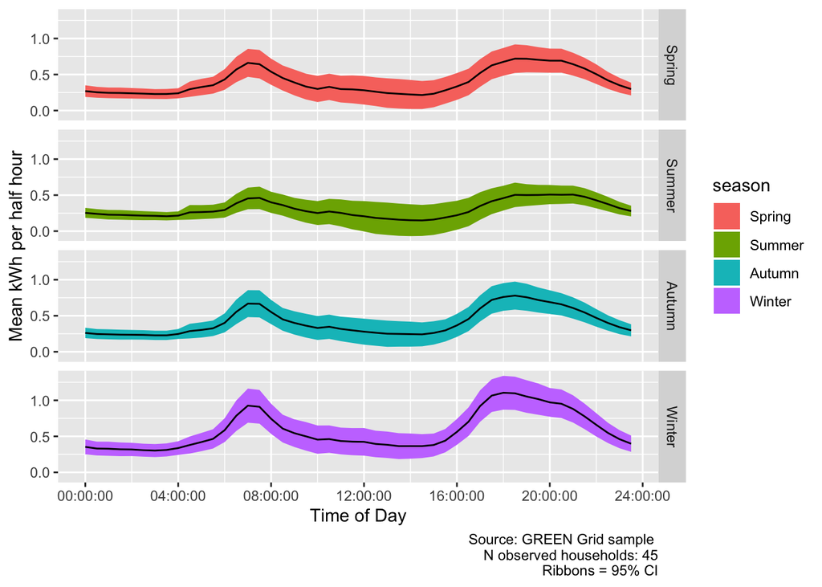

Figure 4.1: Mean total half-hourly kWh per dwelling by season

Figure 4.1 shows the results of the initial sample-based profile calculation. The dark line is the calculated mean with no values excluded whilst the ribbons show the 95% confidence interval for the mean estimate. We estimate that the maximum mean kWh per half-hour in winter in 2015 was ~ 1.11 kWh. If we multiply this by the number of households estimated by the [2015 NZ Statistics household count projection](http://archive.stats.govt.nz/browse_for_stats/population/estimates_and_projections/DwellingHouseholdEstimates_HOTPJun17qtr.aspx) (1,796,000) then we get a rough estimate of maximum mean half-hourly residential kWh in winter of ~1.99 GWh.

Figure 4.2 shows the simple upscaling of Figure 4.1 to the 2015 New Zealand household population by multiplying by the total number of households projected.

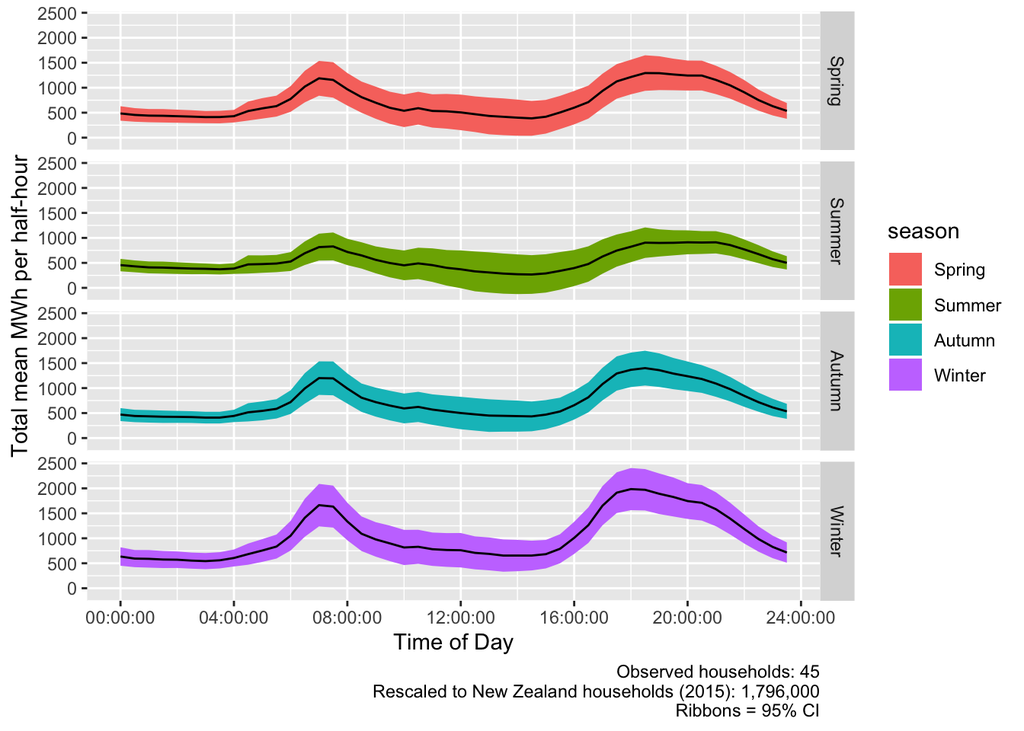

Figure 4.2: Estimated total residential electricity consumption per half-hour by season (simple multiplication, 2015)

As we can see, the uncertainty in the sample estimates are reflected in the upscaled estimates with, for example, the 95% CI for winter at 18:00 is +/- ~20% of the mean (1,560 to ~ 2,410 MWh).

We can then compare the mean values with the overall electricity consumption captured by the 2015 Grid Exit Point (GXP) data used in [Part B](https://cfsotago.github.io/GREENGridEECA/). For clarity we do not include the upweighted 95% CI.Figure 4.3 shows the upweighted mean as a % of the total network electricity export by season for all regions in 2015. We can see that the estimated % contribution of residential dwellings to peak time consumption is ~ 40% in summer but close to 70% in winter with a substantial dip in summer reflecting the ‘overweighting’ of the sample PV dwellings.

In the absence of any other data sources we are unable to comment on the plausibility of these estimates but 70% is likely to be a considerable over-estimate given the non-representative nature of the GREEN Grid sample as reported in Section 3.3 above. This approach illustrates the difficulty of producing robust national level estimates using simple multiplication of a small and biased sample.

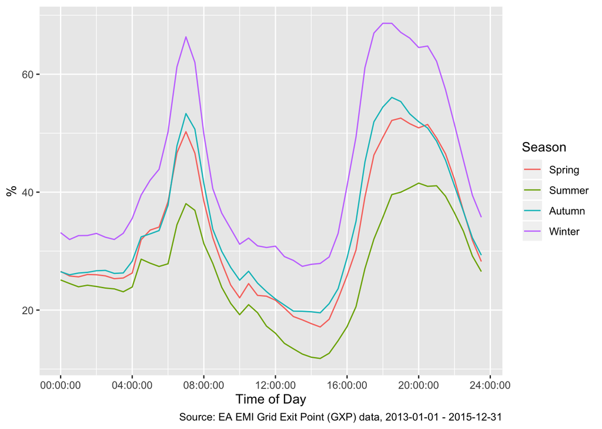

Figure 4.3: Estimated mean total half-hourly residential electricity consumption as a % of GXP mean total by season

Clearly it would be possible to repeat this simple method using projected inter-Censual regional household counts for Taranaki and Hawke’s Bay respectively although again, as shown in Section 3.3, the GREEN Grid sample is not representative of these regions either.

## 4.2 Simple proportional scaling

In this method, rather than assume that the base (GREEN Grid) sample represents all New Zealand consumption profiles and mean values can simply be multiplied by the overall household count, we proportionately adjust the profiles using some other data source to attempt to correct for sample bias. We provide two examples of this below but for simplicity do not include confidence intervals in the presentation of results.

### 4.2.1 Example: Adjusting total consumption for different available heat sources

Table 3.2 showed that there were differences between the GREEN Grid sample and the overall household population in terms of main heat source used. We might expect main space heat source to make a difference to the load profile of the households. In principle we can use this information to proportionately adjust the estimates by calculating overall kWh profiles for each main heat type in the GREEN Grid sample. We would then multiply these different profiles by the number of each household type we would expect in the population calculated by combining Census household counts with HCS 2015 estimates of heat source prevalence (see Table 3.2).

Unfortunately, as Table 3.2 showed, the GREEN Grid sample has too few cases in all but the heat pump category to make this feasible but a larger sample, even if not representative, could be used for this purpose provided all relevant categories are present.

### 4.2.2 Example: Heat pump electricity consumption 2015

As in the previous example, in principle we should estimate heat pump electricity consumption profiles for the owner-occupier and rental dwellings in the GREEN Grid sample to allow for systematic differences. We would then multiply these two profiles by the proportion of dwellings of each type in New Zealand. We can calculate the latter by multiplying household counts for owner-occupied & rental dwellings by the BRANZ percentage estimates. In doing so we would have to assume that the proportions of owner-occupied to rental dwellings had remained constant from 2013 (Census) to 2015 (HCS 2015).

Unfortunately, as Table 4.1 shows, over 90% of GREEN Grid dwellings were owner-occupied and so the approach of calculating different consumption profiles for each tenure type is not feasible. Again, a larger sample would make this possible.

Table 4.1: % dwellings in GREEN Grid sample with/without heat pumps by tenure

|  | No | Yes |
| --- | --- | --- |
|  | 4.5 | 0.0 |
| Own debt-free | 6.8 | 6.8 |
| Own, with mortgage(s) on it | 34.1 | 45.5 |
| Rent (private owner) | 0.0 | 2.3 |

Nevertheless, if we assume there are no systematic differences between the heat pump usage patterns by each tenure type we can continue with the example. To do this we first calculate the overall mean electricity consumption profiles for heat pump circuits based on the GREEN Grid data (Figure 4.4).

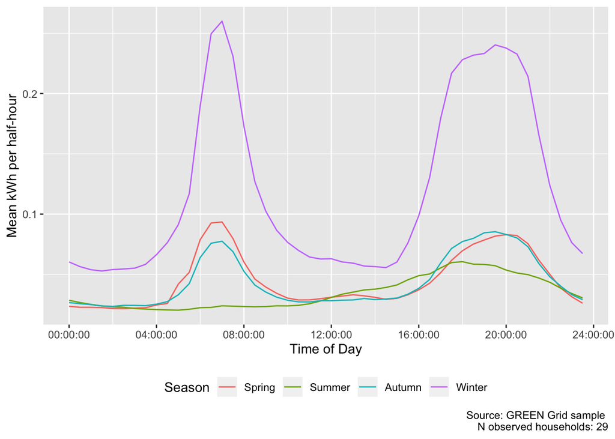

Figure 4.4: Mean half-hourly Heat Pump kWh per dwelling by season

Figure 4.4 shows the results of these initial sample-based profile calculations and we can clearly see the increased electricity consumption of heat pumps in winter with a hint of limited use for late afternoon cooling in summer.

The Census 2013 tells us that 25.2% of households were rentals and 64.8% were owner occupied. In the absence of other data, we assume that the remaining 10% have a similar heat pump distribution to owner-occupier homes. This means that if we apply the HCS 2015 prevalence rates then we have:

- ~1,163,800 owner occupied homes of which ~465,500 have heat pumps
- ~453,100 rental homes of which ~113,300 have heat pumps
- ~179,100 ‘other tenure’ homes of which ~71,600 have heat pumps

Note that whilst this may appear to provide the ability to model the heat (pump) demand of a large proportion of New Zealand dwellings, we should remember that the demand profiles are based on a very small and non-representative sample.

We then multiply each of these ‘heat pump owning’ household counts by the electricity consumption profiles shown in Figure 4.4. This means that we are applying *identical* heat pump demand profiles to all household types even though we might expect that there would be some differences. It would be possible to apply a distribution to these profiles to better account for inter-household heterogeneity or to use a microsimulation approach to do so (see Section 4.3.1) but this is left to future work.

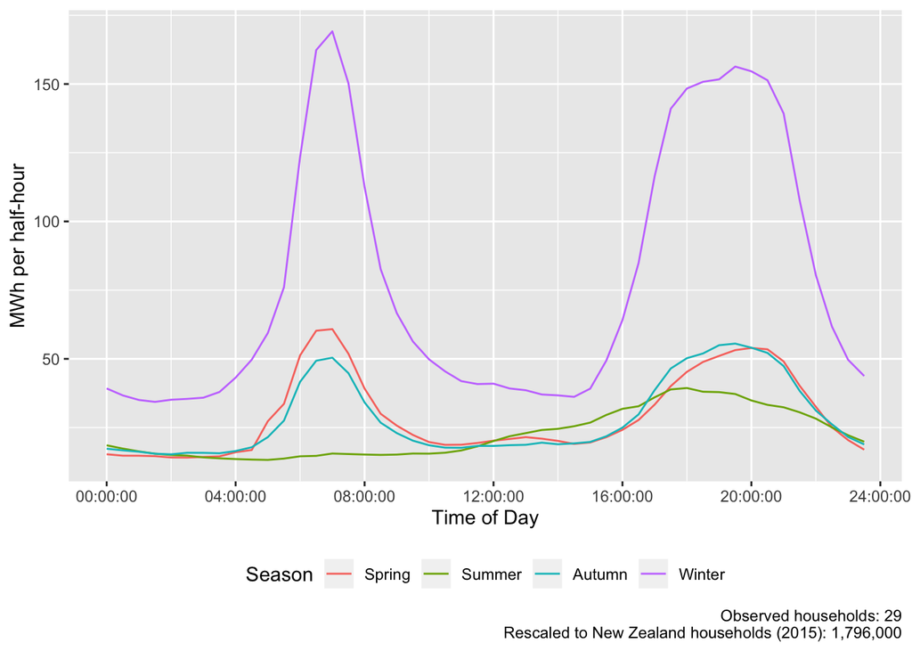

Figure 4.5: Estimated total residential heat pump electricity consumption per half-hour by season (2015)

Figure 4.6 shows these values as a % of the total network electricity export by season for all regions in 2015. We can see that the estimated % contribution of residential dwellings to peak time consumption is small - < 2% in summer but up to just over 7% in winter. In the absence of any other data sources we are unable to comment on the plausibility of these estimates.

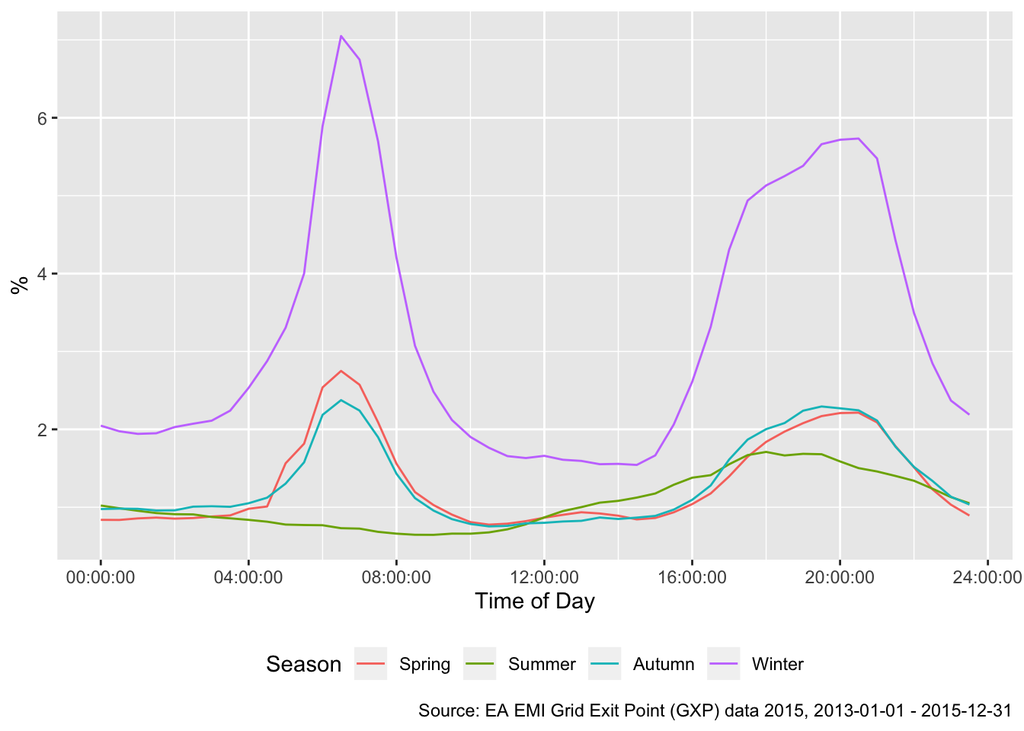

Figure 4.6: Estimated mean total half-hourly residential heat pump electricity consumption as a % of GXP mean total by season

### 4.2.3 Summary

The previous sections have shown that it is possible to conduct simple multiplicative upscaling of sample datasets to produce national or regional estimates. However this is only likely to be robust if:

- samples are *large enough* to ensure that unusual patterns of demand in particular households do not cause the estimates to be skewed;
- samples are nationally or regionally representative.

In the examples provided we have shown how the small sample size also leads to extremely imprecise estimates of national demand which are unlikely to be sufficient for detailed policy or planning purposes.

Further they have shown that where samples are not representative, they can be proportionally upscaled where other sources of data are available. However this can only be done if sufficient dwellings in the under-represented groups exist in the sample and, as we have seen, this is not the case for the GREEN Grid sample.

In addition it should be clear that proportional upscaling as described above can only ‘fix’ one dimension at a time. As noted in Section 3.3, the GREEN Grid sample is not representative at the regional and national levels on a number of dimensions. In this instance more complex re-weighting mechanisms which can adjust for several dimensions at once may be required.

## 4.3 Complex re-weighting

A number of multi-variate weighting schemes have been developed which allow the multiple re-weighting of survey data along several dimensions. Whilst some use forms of regression modelling (Battaglia et al. 2016), others use a conceptually more simple iterative reweighting process. This seeks to calculate weights for each household that, when summed, add up to totals derived from a trusted ‘true’ source such as a high quality national survey or census.

Of the range of methods available to do this, the iterative proportional fitting (IPF) method is well established and appears in a multitude of guises, from balancing factors in spatial interaction modelling through survey raking (re-weighting) (Beaujouan, Brown, and Bhrolcháin 2011; Casati et al. 2015) to the RAS method in economic accounting, and its behaviour is relatively well known (Wong 1992; Simpson and Tranmer 2005).

Further, the IPF approach is well suited to our current purpose where we wish to preserve household level heterogeneity in demand whilst re-weighting to match known Census household distributions at national, regional or small area levels (Simpson and Tranmer 2005; Birkin and Clarke 2011; Anderson 2012, 2019). It is important to note that these calculations involve multiplying individual household kWh values by a set of household level weights and then summing them. This is the inverse of the simple multiplication approach which started from the whole-sample mean and multiplied by a single number (household count). As a result not only do complex re-weighting results tend to preserve inter-household heterogeneity but they allow household level scenarios (e.g. switching from one heat source to another) to be easily implemented for a given proportion of the sample.

In this section we demonstrate the value of this approach in re-weighting the GREEN Grid sample along several dimensions to produce estimates of total electricity consumption for:

- New Zealand
- Taranaki
- Hawke’s Bay
- a set of Census 2013 area units in the Hawke’s Bay region

This is done using a household weights dataset developed using the IPF method which reweight the GREEN Grid dwellings so that they fit the appropriate area level distributions of the following ‘constraint’ variables:

- number of people (1,2,3,4+)
- number of rooms (1-4, 5-6 or 7+)
- number of children (0, 1+)

Whilst it would have been preferable to also re-weight by heat source/space heating method (see Section 3.3.2), the GREEN Grid sample does not contain cases with mainly coal or gas heating that would make this possible. The weights were originally developed under an EU funded MSCA Fellowship ([SPATIALEC](http://www.energy.soton.ac.uk/tag/spatialec/)) and have already been used to estimate household electricity consumption patterns for New Zealand Census 2013 area units (Anderson 2019).

It should be noted that, as reported in Section 3.3, the GREEN Grid sample is sufficiently small and sufficiently different from the overall Census 2013 household proportions on these dimensions that a number of the households are likely to be allocated extremely large weights because we are, in effect, forcing ~ 40 households to represent 1,549,875. As a result, unusual patterns of consumption or, as we will see, generation may well become inflated where the dwellings exhibiting them are disproportionately upweighted due to the rarity of cases. This is described in some detail below.

Finally, we do not attempt to calculate indicators of uncertainty for these estimates. Since the process effectively creates a synthetic Census population, confidence intervals based on the usual statistical sampling theories do not apply. The development of alternative ‘credible intervals’ is the subject of ongoing methodological research (Whitworth et al. 2017; Tanton 2018) and a number of alternatives are emerging that could be implemented in future work.

### 4.3.1 Example: Total residential electricity consumption 2015

#### 4.3.1.1 National estimates

In this example we use the household weights previously developed using the NZ Census 2013, the GREEN Grid sample and the IPF method to reweight the GREEN Grid sample so that it fits to the national 2013 NZ census distributions of the variables listed above.

Table 4.2: Summary of household level IPF weights required to re-weight the GREEN Grid sample to the national household population

|  | linkID | ipfWeight |
| --- | --- | --- |
|  | Length:42 | Min. : 4685 |
|  | Class :character | 1st Qu.: 20887 |
|  | Mode :character | Median : 20887 |
|  | NA | Mean : 36891 |
|  | NA | 3rd Qu.: 37254 |
|  | NA | Max. :240013 |

As 4.2 shows, the household level weights required range from ~4,700 for relatively common combinations of the constraint variables to ~240,000 for less common combinations. Clearly, this is a direct consequence of the extremely small size of the GREEN Grid sample.

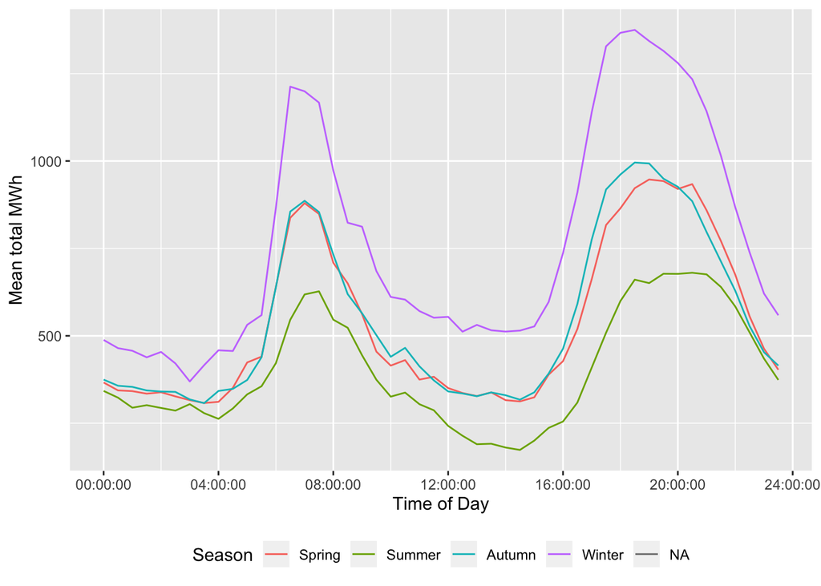

Figure 4.7: Estimated total residential electricity consumption per half-hour by season (IPF, 2015)

As we can see the IPF method produces lower overall consumption estimates and this appears to be especially the case during the day in summer. This is likely to be caused by the upweighting of the four PV-equipped dwellings which we note tend to have larger weights (see Table 6.1 in the Data Annex) although we note that the IPF results are generally lower at all times of day and in all seasons.

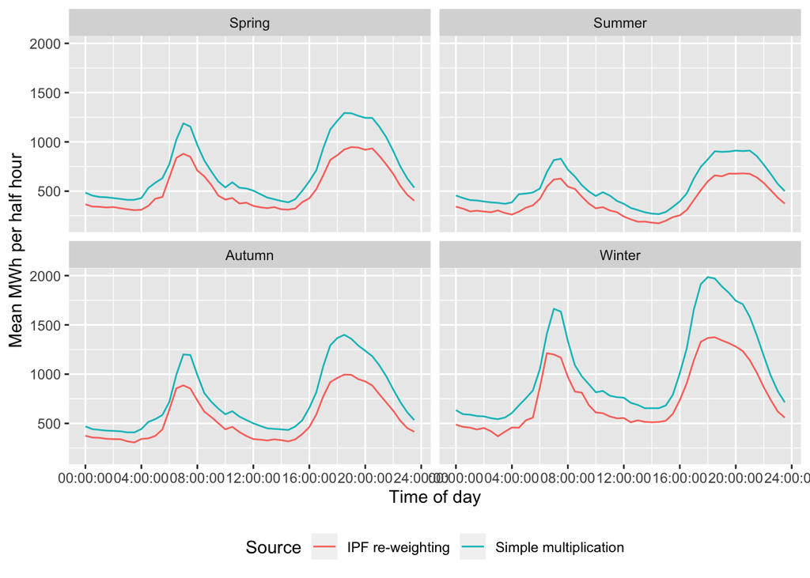

Figure 4.8: Comparison of simple multiplicative and IPF- reweighting based results

Table 4.3: Summary of national level half-hourly MWh estimates by source

| source | Min MWh | Mean MWh | Max MWh |
| --- | --- | --- | --- |
| IPF re-weighting | 173.5503 | 563.4494 | 1375.032 |
| Simple multiplication | 267.3003 | 762.4496 | 1984.723 |

Table 4.4: Weighted number of GREEN Grid households with PV inverter (IPF results, rounded)

| PV Inverter | nHouseholds |
| --- | --- |
| No | 1333400 |
| Yes | 216000 |

As before, in the absence of other data sources it is not possible to comment on the plausibility of these estimates. However we note that the IPF process combined with the non-representative GREEN Grid sample has, in effect, created a scenario where ~216,000 have PV installed (Table 4.4). This is roughly 10 times the total estimated [2018 New Zealand installation level](https://www.mysolarquotes.co.nz/blog/solar-power-new-zealand/new-zealand-solar-power-systems-in-2018-slowly-but-surely/?keyword=2018/) for both residential and commercial sites combined. As a result Figure 4.7 and Figure 4.8 illustrate one possible future residential electricity demand scenario for New Zealand should PV installation rates continue to rise as they have (Ford et al. 2017).

Whilst it would be possible to compare the IPF results with the GXP grid export data (c.f. Section 4.1.1), it does not seem appropriate to do so given the increase in PV generation apparently embedded within the IPF-based results. This would reduce the GXP level electricity flows due to increased local generation and thus reduce overall GXP level ‘consumption’ below that observed for 2015. Modelling the effect of such local embedded generation on GXP level flows based on upscaled samples such as GREEN grid could therefore be the subject of future work.

#### 4.3.1.2 Regional estimates

In this example we use the IPF method to reweight the GREEN Grid sample so that it fits to the 2013 NZ census distributions of the variables listed above at the regional levels. It is usually considered best practice to use sample households from a given region to represent that region in this process. However the very small number of households in the GREEN Grid sample mean this is not feasible and must be left to future work using larger regionally representative samples.

Whilst this process adjusts the GREEN Grid households to fit each region separately according to the dimensions listed above, it cannot account for the regional spatial distribution of different energy infrastructures (e.g. reticulated gas etc - see Section 3.3) because there are not enough (or no) cases in the GREEN Grid sample representing these types of households.

Table 4.5: Summary of household level IPF weights required to re-weight the GREEN Grid sample to the regional household populations

|  | REGC2013_label | linkID | ipfWeight |
| --- | --- | --- | --- |
|  | Length:714 | Length:714 | Min. : 0.64 |
|  | Class :character | Class :character | 1st Qu.: 219.36 |
|  | Mode :character | Mode :character | Median : 690.87 |
|  | NA | NA | Mean : 2170.03 |
|  | NA | NA | 3rd Qu.: 2152.72 |
|  | NA | NA | Max. :57340.45 |

As 4.5 shows, in this case the household level weights required range from ~0 to ~57,300.

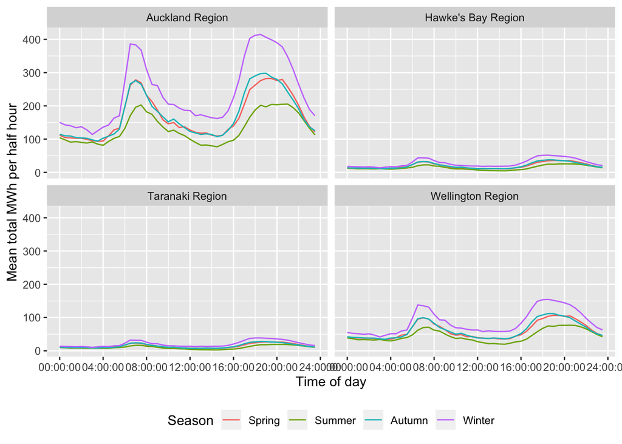

Figure 4.9: Estimated total residential electricity consumption per half-hour by season for selected regions (IPF, 2015)

Figure 4.9 shows the resulting total residential electricity consumption profiles by season for Hawke’s Bay and Taranaki (the regions from which the GREEN Grid sample was drawn) and also for Wellington and Auckland for comparison. Clearly levels of consumption are driven by the population sizes and the shapes of the curves are similar largely due to:

- our inability to adjust for different levels of heating and other appliances in each region;
- the need to use households from the Taranaki and Hawke’s Bay regions (GREEN Grid sample) to represent households from Auckland and Wellington who may experience very different environmental conditions or have very different housing stock performance.

Again we have no data that can be used to validate these results given the apparent increase in embedded generation that is included.

#### 4.3.1.3 Census area unit estimates

Finally, in this section we use the same method to calculate total residential electricity consumption profiles by season for a subset of Hawke’s Bay Census area units. Area units are the second smallest New Zealand census output zones with a mean household count of ~ 750 (See Table 4.6).

Table 4.6: Number of households and number of area units by region (Census 2013)

| REGC2013_label | nHouseholds | nAUs | meanHouseholdsPerAU |
| --- | --- | --- | --- |
| Auckland Region | 469530 | 437 | 1074.4 |
| Canterbury Region | 204843 | 258 | 794.0 |
| Wellington Region | 176112 | 213 | 826.8 |
| Waikato Region | 150156 | 209 | 718.4 |
| Bay of Plenty Region | 102273 | 129 | 792.8 |
| Manawatu-Wanganui Region | 86982 | 129 | 674.3 |
| Otago Region | 78882 | 132 | 597.6 |
| Northland Region | 58941 | 97 | 607.6 |
| Hawke’s Bay Region | 57654 | 84 | 686.4 |
| Taranaki Region | 43032 | 66 | 652.0 |
| Southland Region | 37458 | 79 | 474.2 |
| Nelson Region | 18543 | 31 | 598.2 |
| Tasman Region | 18264 | 30 | 608.8 |
| Marlborough Region | 17670 | 26 | 679.6 |
| Gisborne Region | 16005 | 24 | 666.9 |
| West Coast Region | 13281 | 57 | 233.0 |
| Area Outside Region | 249 | 19 | 22.6 |

As 4.7 shows, in the case of Hawke’s Bay, the weights have smaller values as we are using the ~40 GREEN Grid households to represent on average ~ 680 households (see Table 4.6).

Table 4.7: Summary of linked GREEN Grid household consumption data and area unit level weights

|  | linkID | meankWh | ipfWeight |
| --- | --- | --- | --- |
|  | Length:595374 | Min. :-2.2140 | Min. : 0.000 |
|  | Class :character | 1st Qu.: 0.2278 | 1st Qu.: 2.674 |
|  | Mode :character | Median : 0.3669 | Median : 8.424 |
|  | NA | Mean : 0.4336 | Mean : 17.181 |
|  | NA | 3rd Qu.: 0.6034 | 3rd Qu.: 18.818 |
|  | NA | Max. : 2.4980 | Max. :545.710 |
|  | NA | NA’s :78 | NA |

Rather than show the results for all area units in Hawke’s Bay we select the two which have the highest and lowest proportions of 4+ occupants (see Table 4.8). This should enable us to see differences in are unit level profiles which correlate with different area level household composition.

Figure 4.10 shows the total MWh seasonal residential electricity consumption profiles for these two areas and we can clearly see that they are both downscaled versions of the regional profiles (Figure 4.9). We can also see that as we would expect, the area unit with the lowest proportion of 4+ occupants (and the lowest total number of households) has the lowest consumption profile.

Table 4.8: Selected area units with highest and lowest % of large (4+ person) households (areas with more than 500 households)

| AU2013_label | nPeople_1 | nPeople_2 | nPeople_3 | nPeople_4m | npeople_totalHouseholds | pc_nPeople_4m |
| --- | --- | --- | --- | --- | --- | --- |
| Kingsley-Chatham | 102 | 213 | 168 | 357 | 837 | 42.7 |
| Ahuriri | 216 | 204 | 48 | 39 | 501 | 7.8 |

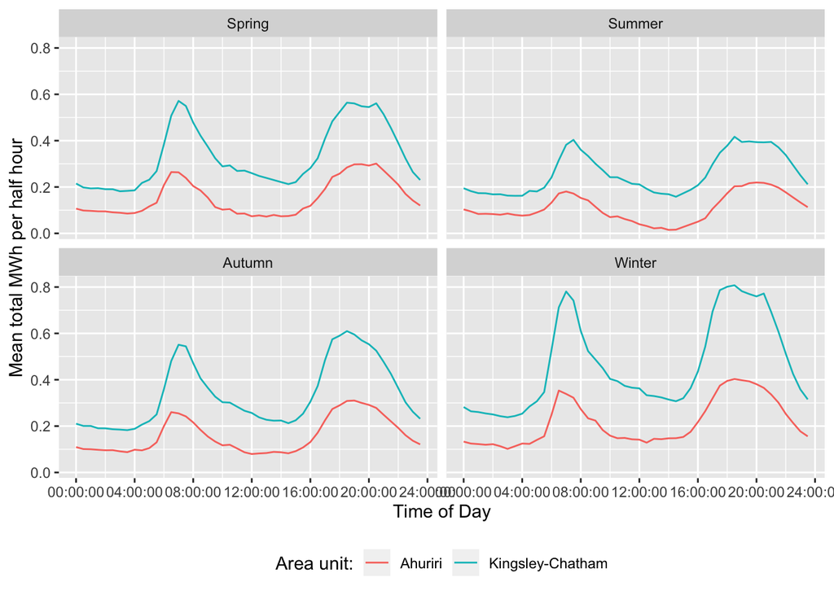

Figure 4.10: Estimated total residential electricity consumption per half-hour by season for selected area units (IPF, 2015)

As before, it should be noted that this approach is applying the electricity consumption profiles of the GREEN Grid sample to these area units and adjusting *only* for the census constraints chosen (number of children, rooms and people). It is *not* adjusting for local area variation in energy infrastructures, micro-climate or any other factor that is not correlated with these constraints. Given this and also the earlier discussion of the prevalence of PV generation in this sample, the results should be viewed with extreme caution.

Clearly this method could be used to produce similar profiles for each area unit (or even mesh block) in New Zealand but this would mean assuming that the GREEN Grid electricity consumption profiles can be unproblematically applied to area units in Northland, Southland and all places in between. Given the known spatial heterogeneity of heat sources, winter temperatures and day length (for example) this assumption appears implausible.

On the other hand the method and the GREEN grid sample can be used to develop area unit level profiles for the regions from which the sample is drawn, although even in this case the non-representative and extremely small sample means the results could not be considered robust (Anderson 2019).

### 4.3.2 Summary

Overall we have shown that it is possible to use complex multi-variate re-weighting to upscale small samples to produce national, regional or local electricity demand profiles. However, as in previous sections the robustness of the results depends entirely on the representativeness of the sample and its ability to include (and represent) sub-groups of households of interest - such as those with different main heat sources. In addition the methods require that relevant ‘constraints’ are available from Census or similar data. While this is true of ‘available heating fuel’ in the 2013 Census, the inclusion of information on [heating appliances](https://www.branz.co.nz/cms_show_download.php?id=f3d23ecb6c7d36efff1fae3c1ee19893735998c6) in Census 2018 means that it may be possible to produce more robust local demand profiles in future.

# 5 Overall summary and recommendations

This report has outlined a number of methods that could be used to upscale the GREEN Grid (or similar) household energy demand datasets to develop national or regional level residential demand or consumption estimates. However we have noted that in all cases the GREEN grid data is insufficient for this purpose due to:

- its small size - meaning very small numbers of households would be ‘representing’ very large numbers in the true population with a consequential risk of both skew and a lack of precision;
- its recruitment bias - meaning that some household types and some crucial energy source types (e.g. coal, wood-only, reticulated gas) are not represented at all and so cannot be ‘re-weighted’.

We have demonstrated this through a number of worked examples and suggest that future work could apply these methods to more suitable larger scale data sources such as:

- the BRANZ [Housing Conditions Survey](https://www.branz.co.nz/hcs) datasets - although detailed energy monitoring was not included;
- the recent NZ Stats/MBIE [Housing Quality Indicator survey](https://www.stats.govt.nz/methods/framework-for-housing-quality) - although detailed energy monitoring was not included;
- the potential future population representative BRANZ Household Energy End-Use (HEEP2) study;
- representative smart meter datasets linked to household attributes;
- imputed load profiles generated using population representative New Zealand Time Use diary data (see (McKenna and Thomson 2016; McKenna et al. 2017) for a UK example)

Would these samples be large *enough* for these purposes? Unfortunately there is no simple answer to this question since it is likely that the size of the chosen sample will depend on the precision of the estimates required. For example, in Section 3.3 we noted that the BRANZ Housing Condition Survey 2015 sample size of 560 dwellings enabled a precision (95% confidence interval) of +/- 5% for overall sample statistics but +/- 6% and +/- 11% for the smaller owned and rental subgroups (Vicki White and Mark Jones 2017). As shown in Figure 3.2 this means that the percentage of owner-occupied dwellings with heat pumps (for example) can only be estimated to lie between 34% and 46% (lower and upper 95% intervals). If greater precision is required at the whole sample or sub-group levels then larger samples will be needed and there are a number of recent papers which can provide guidance in this regard (Sovacool, Axsen, and Sorrell 2018; Anderson et al. 2020).

However, in the case of multivariate upscaling (Section 4.3) it is clear that a representative sample would also need to be large enough to include sufficient numbers of households to represent key sub-groups of interest (i.e. reweighting constraints) at the required level of precision. In the work reported above this is evident in the inability to re-weight the GREEN Grid sample to fit national, regional or local distributions of space heating appliance or even main heating fuel source due to an absence of representative cases. As noted, no method can re-weight households types that are absent from the sample…

Nevertheless, we have also demonstrated that small and biased samples such as GREEN Grid can be used to create scenarios of future demand at national, regional or small area (neighbourhood) levels:

- where the sample comprises a set of households specifically chosen to represent ‘the future’, methods such as IPF can be used to develop plausible estimates of their future demand profiles;
- where it does not, specific household attributes can be changed in specific households in the sample and the consequences upscaled to local, regional or national estimates - an approach known as spatial microsimulation (Birkin and Clarke 2011).

We would suggest that modelling a range of future scenarios using the GREEN Grid sample could take this approach and we have noted a number of potential avenues including the effect of large-scale PV installation on regional (or local area) electricity flows. This work could include adjusting the total load estimates to reflect gross rather than net load for those households with PV (see 4.1.1) and the use of regionally representative households to ensure geographically accurate generation and consumption patterns (see 4.3.1.2).

Other possible avenues could include the effects of wide-scale EV uptake or energy efficiency interventions such as LED light-bulbs (building on (Dortans 2019)) or transition from radiant electric heating to heat pumps. Further, with the potential release of updated Census 2018 data on [heating appliances](https://www.branz.co.nz/cms_show_download.php?id=f3d23ecb6c7d36efff1fae3c1ee19893735998c6), it may also be possible to produce substantially more precise (and robust) estimates of regional and local demand profiles for electric heating of various kinds. As part of this, it would also be possible to introduce microsimulation or statistical distribution-based methods to model inter-household heterogeneity and to implement emerging ‘credible intervals’ to give indicators of regional uncertainty in the estimates.

# 6 Data Annex

## 6.1 Census data summary

Descriptive statistics for census data:

```
## Skim summary statistics
##  n obs: 2020
##  n variables: 35
##
## ── Variable type:character ──────────────────────────────────────────────────────────────────────────────────────────────
##        variable missing complete    n min max empty n_unique
##    AU2013_label       0     2020 2020   4  34     0     2020
##  REGC2013_label       0     2020 2020  12  24     0       17
##
## ── Variable type:integer ────────────────────────────────────────────────────────────────────────────────────────────────
##                      variable missing complete    n      mean       sd
##                   AU2013_code       0     2020 2020 558310.19 36014.2
##                       calcSum       8     2012 2020    776.19   624.19
##          fuel_totalHouseholds       8     2012 2020    776.29   623.96
##    fuel_totalStatedHouseholds       8     2012 2020    733.37   590.5
##                heatSourceCoal       8     2012 2020     30.3     62.1
##         heatSourceElectricity       8     2012 2020    592.64   498.79
##                 heatSourceGas       8     2012 2020    200.97   205.12
##               heatSourceOther       8     2012 2020     76.61    98.01
##                heatSourceWood       8     2012 2020    269.51   245.25
##                     i.calcSum       8     2012 2020    770.13   618.81
##                   i.calcSum.1       8     2012 2020   1170.03   898.84
##                   i.calcSum.2       8     2012 2020    564.81   452.99
##                 i.calcSumPc.2     134     1886 2020    100        0
##                       nKids_0       8     2012 2020    508.75   433.1
##              nKids_0_families       8     2012 2020    303.24   247
##                      nKids_1m       8     2012 2020    261.57   220.29
##           nkids_totalFamilies       8     2012 2020    564.81   452.99
##         nkids_totalHouseholds       8     2012 2020    770.32   618.78
##                          nMBs       0     2020 2020     23.09    16.9
##                     nPeople_1       8     2012 2020    176.58   168.71
##                     nPeople_2       8     2012 2020    262.21   217.39
##                     nPeople_3       8     2012 2020    126.64   106.58
##                    nPeople_4m       8     2012 2020    204.7    182.03
##       npeople_totalHouseholds       8     2012 2020    770.32   618.78
##  nrooms_statedtotalHouseholds       8     2012 2020    731.16   589.34
##        nrooms_totalHouseholds       8     2012 2020    776.29   623.96
##                     nRooms1_4       8     2012 2020    121.33   182.91
##                     nRooms5_6       8     2012 2020    312.3    263.44
##                      nRooms7m       8     2012 2020    342.56   285.93
```

[output cut: 27 more lines]

```
##      0     24        72      165      4122 ▇▁▁▁▁▁▁▁
##      0     84       261      489      1758 ▇▅▃▂▁▁▁▁
##      0    108       297      504.75   1992 ▇▆▃▁▁▁▁▁
##
## ── Variable type:numeric ────────────────────────────────────────────────────────────────────────────────────────────────
##       variable missing complete    n   mean    sd p0    p25    p50    p75
##      calcSumPc     131     1889 2020  98.5  12.46  0  99.69 100    100.28
##    i.calcSumPc     124     1896 2020  98.39 12.52  0  99.69 100    100.24
##  i.calcSumPc.1     131     1889 2020 154.81 25.82  0 141.04 153.8  167.98
##  pc_nPeople_4m     124     1896 2020  25.38 10.35  0  19.41  24.91  30.75
##    p100     hist
##  137.5  ▁▁▁▁▁▇▁▁
##  125    ▁▁▁▁▁▁▇▁
##  233.33 ▁▁▁▁▅▇▂▁
##   80    ▁▃▇▃▁▁▁▁
```

## 6.2 GREEN Grid half-hourly total load summary

Descriptive statistics for dwelling half hourly overall kWh data:

```
## Skim summary statistics
##  n obs: 1770614
##  n variables: 15
##
## ── Variable type:character ──────────────────────────────────────────────────────────────────────────────────────────────
##      variable missing complete       n min max empty n_unique
##       circuit       0  1770614 1770614  37  37     0        1
##  circuitLabel       0  1770614 1770614  37  37     0        1
##   eecaCircuit       0  1770614 1770614   5   5     0        1
##        linkID       0  1770614 1770614   5   6     0       45
##
## ── Variable type:Date ───────────────────────────────────────────────────────────────────────────────────────────────────
##  variable missing complete       n        min        max     median
##      date       0  1770614 1770614 2014-01-06 2018-08-01 2016-03-13
##  n_unique
##      1613
##
## ── Variable type:difftime ───────────────────────────────────────────────────────────────────────────────────────────────
##  variable missing complete       n    min        max     median n_unique
##       hms       0  1770614 1770614 0 secs 84600 secs 43200 secs       48
##
## ── Variable type:factor ─────────────────────────────────────────────────────────────────────────────────────────────────
##  variable missing complete       n n_unique
##    season       0  1770614 1770614        4
##                                          top_counts ordered
##  Win: 488290, Aut: 454306, Spr: 430353, Sum: 397665   FALSE
##
## ── Variable type:integer ────────────────────────────────────────────────────────────────────────────────────────────────
##  variable missing complete       n  mean   sd p0 p25 p50 p75 p100     hist
##      nObs       0  1770614 1770614 30.23 2.83  1  30  30  30   60 ▁▁▁▇▁▁▁▁
##
## ── Variable type:logical ────────────────────────────────────────────────────────────────────────────────────────────────
##   variable missing complete       n mean   count
##  circuitID 1770614        0 1770614  NaN 1770614
##
## ── Variable type:numeric ────────────────────────────────────────────────────────────────────────────────────────────────
##    variable missing complete       n    mean      sd        p0    p25
##   maxPowerW       0  1770614 1770614 1675.04 1749.32  -6970.85 378.08
##     meankWh       0  1770614 1770614    0.43    0.58     -3.81   0.13
##  meanPowerW       0  1770614 1770614  863.39 1156.8   -7627.66 250.2
##   minPowerW       0  1770614 1770614  397.11  957.93 -12407.52 122.81
##    sdPowerW     101  1770513 1770614  411.54  470.71      0     61.4
##     p50     p75     p100     hist
##  973.47 2723.49 15593.2  ▁▁▇▅▁▁▁▁
##    0.26    0.62     5.49 ▁▁▁▇▂▁▁▁
##  512.88 1238.96 10981.59 ▁▁▁▇▂▁▁▁
##  242.9   519.99  9600.58 ▁▁▁▁▇▁▁▁
##  145.74  706.27  4954    ▇▂▁▁▁▁▁▁
##
## ── Variable type:POSIXct ────────────────────────────────────────────────────────────────────────────────────────────────
##            variable missing complete       n        min        max
##  r_dateTimeHalfHour       0  1770614 1770614 2014-01-06 2018-08-01
##      median n_unique
##  2016-03-13    77345
```

Descriptive statistics for dwelling half hourly heat pump kWh data:

```
## Skim summary statistics
##  n obs: 1342357
##  n variables: 14
##
## ── Variable type:character ──────────────────────────────────────────────────────────────────────────────────────────────
##      variable missing complete       n min max empty n_unique
##       circuit       0  1342357 1342357  14  35     0       35
##  circuitLabel       0  1342357 1342357   9  30     0       17
##        linkID       0  1342357 1342357   5   6     0       29
##
## ── Variable type:Date ───────────────────────────────────────────────────────────────────────────────────────────────────
##  variable missing complete       n        min        max     median
##      date       0  1342357 1342357 2014-05-29 2018-08-01 2016-05-02
##  n_unique
##      1525
##
## ── Variable type:difftime ───────────────────────────────────────────────────────────────────────────────────────────────
##  variable missing complete       n    min        max   median n_unique
##       hms       0  1342357 1342357 0 secs 84600 secs 12:00:00       48
##
## ── Variable type:factor ─────────────────────────────────────────────────────────────────────────────────────────────────
##  variable missing complete       n n_unique
##    season       0  1342357 1342357        4
##                                          top_counts ordered
##  Win: 369994, Aut: 345402, Spr: 327971, Sum: 298990   FALSE
##
## ── Variable type:integer ────────────────────────────────────────────────────────────────────────────────────────────────
##   variable missing complete       n    mean     sd   p0  p25  p50  p75
##  circuitID       0  1342357 1342357 3399.98 870.66 2092 2598 4130 4186
##       nObs       0  1342357 1342357   29.99   0.5     1   30   30   30
##  p100     hist
##  4399 ▃▂▃▁▁▁▁▇
##    60 ▁▁▁▇▁▁▁▁
##
## ── Variable type:numeric ────────────────────────────────────────────────────────────────────────────────────────────────
##    variable missing complete       n    mean     sd       p0 p25   p50
##   maxPowerW       0  1342357 1342357 230.23  536.16 -2228.29   0 15.14
##     meankWh       0  1342357 1342357   0.063   0.17    -1.17   0  0
##  meanPowerW       0  1342357 1342357 126.1   332.28 -2343.79   0  0
##   minPowerW       0  1342357 1342357  57.07  245.18 -3973.34   0  0
##    sdPowerW      21  1342336 1342357  55.65  140.97     0      0  1.38
##      p75     p100     hist
##  185.48  27759    ▇▁▁▁▁▁▁▁
##    0.053     2.67 ▁▁▇▁▁▁▁▁
##  106.06   5340.91 ▁▁▇▁▁▁▁▁
##   37      4860.41 ▁▁▁▇▁▁▁▁
##   41.32   5068.08 ▇▁▁▁▁▁▁▁
##
## ── Variable type:POSIXct ────────────────────────────────────────────────────────────────────────────────────────────────
##            variable missing complete       n        min        max
##  r_dateTimeHalfHour       0  1342357 1342357 2014-05-29 2018-08-01
##      median n_unique
##  2016-05-02    73166
```

## 6.3 GREEN Grid household data summary

Descriptive statistics for household data:

```
## Skim summary statistics
##  n obs: 44
##  n variables: 123
##
## ── Variable type:character ──────────────────────────────────────────────────────────────────────────────────────────────
##             variable missing complete  n min max empty n_unique
##        Clothes Dryer       0       44 44   0   3    23        2
##           Dishwasher       0       44 44   0   3    15        2
##      Electric heater       0       44 44   0   3    30        2
##       Energy Storage       0       44 44   0   3    43        2
##   Fridge / Freezer 1       0       44 44   0   3    13        2
##   Fridge / Freezer 2       0       44 44   0   3    24        2
##   Fridge / Freezer 3       0       44 44   0   3    38        2
##  hasApplianceSummary       0       44 44   0   3    13        2
##          hasHeatPump       0       44 44   2   3     0        2
##        hasLongSurvey       0       44 44   0   3    15        2
##       hasShortSurvey       0       44 44   0   3    31        2
##   Heated towel rails       0       44 44   0   3    23        2
##                 hhID       0       44 44   5   5     0       42
##   Hot water cylinder       0       44 44   0   3    16        2
##               linkID       0       44 44   5   6     0       44
##             Location       0       44 44   8  10     0        2
##            Microwave       0       44 44   0   3    14        2
##                notes       0       44 44   0 113    39        6
##      Other Appliance       0       44 44   0  42    30        9
##                 Oven       0       44 44   0   3    14        2
##          PV Inverter       0       44 44   2   3     0        2
##            Q12_coded       0       44 44   0  27     2        4
##            Q20_coded       0       44 44   0  31     2        9
##            Q49_coded       0       44 44   0  19     2        5
##           r_stopDate       0       44 44   0  10    41        4
##            StartDate       0       44 44   0  16     2       43
##      surveyStartDate       0       44 44   0  20     2       43
##      Washing Machine       0       44 44   0   3    13        2
##
## ── Variable type:integer ────────────────────────────────────────────────────────────────────────────────────────────────
##          variable missing complete  n    mean     sd p0    p25   p50
##  Heat pump number      19       25 44   1.16    0.55  1   1      1
##           nAdults       1       43 44   1.93    0.51  1   2      2
##     nChildren0_12       2       42 44   1.02    1.02  0   0      1
```

[output cut: 166 more lines]

```
##  Other Generation Device      44        0 44  NaN    44
##                   Q19_10      44        0 44  NaN    44
##                 Q19_10.1      44        0 44  NaN    44
##                   Q19_17      44        0 44  NaN    44
##                    Q19_2      44        0 44  NaN    44
##                    Q19_5      44        0 44  NaN    44
##                    Q19_9      44        0 44  NaN    44
##
## ── Variable type:numeric ────────────────────────────────────────────────────────────────────────────────────────────────
##     variable missing complete  n mean   sd p0 p25 p50 p75 p100     hist
##  Electricity       6       38 44 1    0     1   1 1     1    1 ▁▁▁▇▁▁▁▁
##          Gas      36        8 44 1    0     1   1 1     1    1 ▁▁▁▇▁▁▁▁
##        Other      36        8 44 1    0     1   1 1     1    1 ▁▁▁▇▁▁▁▁
##        Q14_1      15       29 44 5.28 5.03  0   1 3.5   7   20 ▇▆▅▂▁▁▁▁
##         Wood      28       16 44 1    0     1   1 1     1    1 ▁▁▁▇▁▁▁▁
```

## 6.4 GREEN Grid/SPATIALEC ipf household weights

Descriptive statistics for ipf-derived weights:

```
## Skim summary statistics
##  n obs: 78078
##  n variables: 6
##
## ── Variable type:character ──────────────────────────────────────────────────────────────────────────────────────────────
##        variable missing complete     n min max empty n_unique
##    AU2013_label       0    78078 78078   4  33     0     1859
##          linkID       0    78078 78078   5   6     0       42
##  REGC2013_label       0    78078 78078  12  24     0       17
##
## ── Variable type:integer ────────────────────────────────────────────────────────────────────────────────────────────────
##     variable missing complete     n      mean       sd    p0    p25    p50
##  AU2013_code       0    78078 78078 554468.19 33426.1  5e+05 524711 551030
##         nMBs       0    78078 78078     24.75    16.54     1     11     22
##     p75   p100     hist
##  584936 622201 ▇▇▇▅▆▇▆▃
##      35    124 ▇▇▅▁▁▁▁▁
##
## ── Variable type:numeric ────────────────────────────────────────────────────────────────────────────────────────────────
##   variable missing complete     n  mean    sd      p0 p25  p50   p75
##  ipfWeight       0    78078 78078 19.84 37.87 2.6e-75 3.3 9.88 20.64
##     p100     hist
##  1973.35 ▇▁▁▁▁▁▁▁
```

Table 6.1: Household level ipfWeights for national rescaling with example household attributes (oredered by ipfWeight)

| linkID | ipfWeight | PV Inverter | notes |
| --- | --- | --- | --- |
| rf_26 | 240012.522 | No |  |
| rf_34 | 129880.847 | No |  |
| rf_12 | 90514.934 | No |  |
| rf_15a | 90514.934 | No | Disconnected 15/01/2015 |
| rf_19 | 87095.568 | Yes |  |
| rf_23 | 87095.568 | Yes |  |
| rf_09 | 59059.202 | No |  |
| rf_16 | 54636.578 | No |  |
| rf_06 | 37254.174 | No |  |
| rf_08 | 37254.174 | No |  |
| rf_15b | 37254.174 | No | Re-used 15. Then disconnected 02/04/2016 |
| rf_21 | 37254.174 | No |  |
| rf_22 | 37254.174 | No |  |
| rf_40 | 37254.174 | No |  |
| rf_07 | 20886.696 | No |  |
| rf_13 | 20886.696 | No |  |
| rf_17a | 20886.696 | No | Unusual & specialist energy tech configuration. Disconnected 28/03/2016. |
| rf_24 | 20886.696 | Yes |  |
| rf_27 | 20886.696 | No |  |
| rf_28 | 20886.696 | Yes |  |
| rf_30 | 20886.696 | No |  |
| rf_31 | 20886.696 | No |  |
| rf_32 | 20886.696 | No |  |
| rf_33 | 20886.696 | No |  |
| rf_35 | 20886.696 | No |  |
| rf_37 | 20886.696 | No |  |
| rf_38 | 20886.696 | No |  |
| rf_39 | 20886.696 | No |  |
| rf_41 | 20886.696 | No |  |
| rf_42 | 20886.696 | No |  |
| rf_44 | 20886.696 | No |  |
| rf_45 | 20886.696 | No |  |
| rf_47 | 20886.696 | No |  |
| rf_20 | 14998.792 | No |  |
| rf_10 | 10975.493 | No |  |
| rf_18 | 10975.493 | No |  |
| rf_29 | 10975.493 | No |  |
| rf_36 | 10975.493 | No |  |
| rf_43 | 10975.493 | No |  |
| rf_46 | 10975.493 | No | very large number of circuits including voltage and reactive (imaginary) power and possible typos or relabelling? |
| rf_14 | 4684.929 | No |  |
| rf_25 | 4684.929 | No |  |
| rf_11 | NA | No |  |
| rf_17b | NA | No | Re-used 17 |

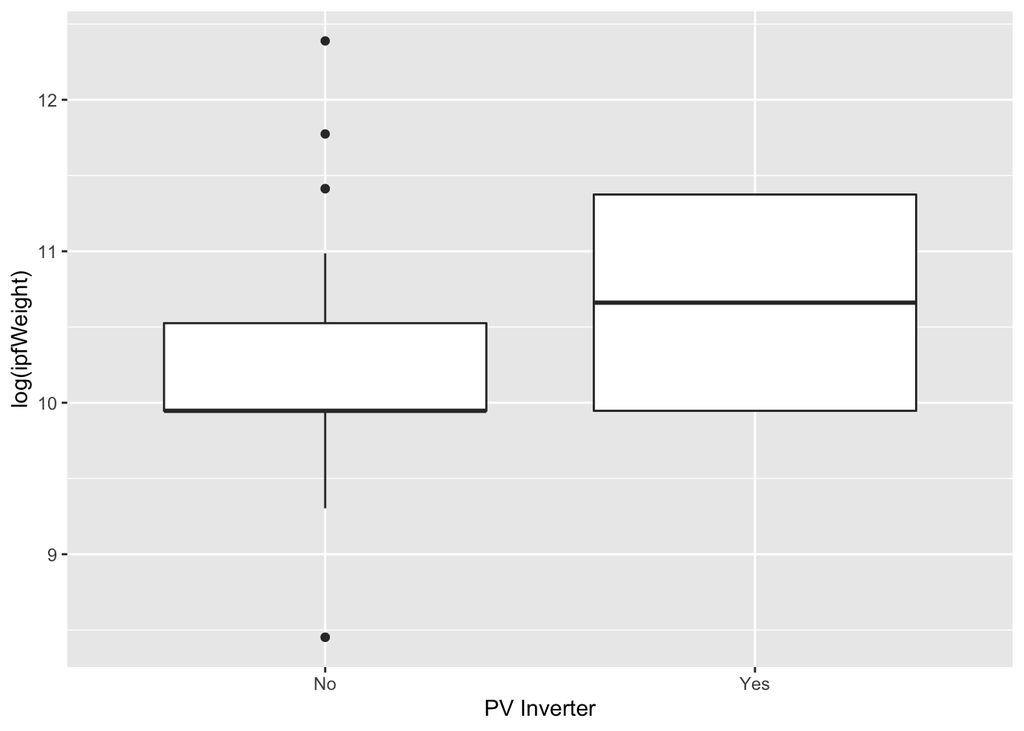

Figure 6.1: Box plot of ipf weights by PV inverter ownership

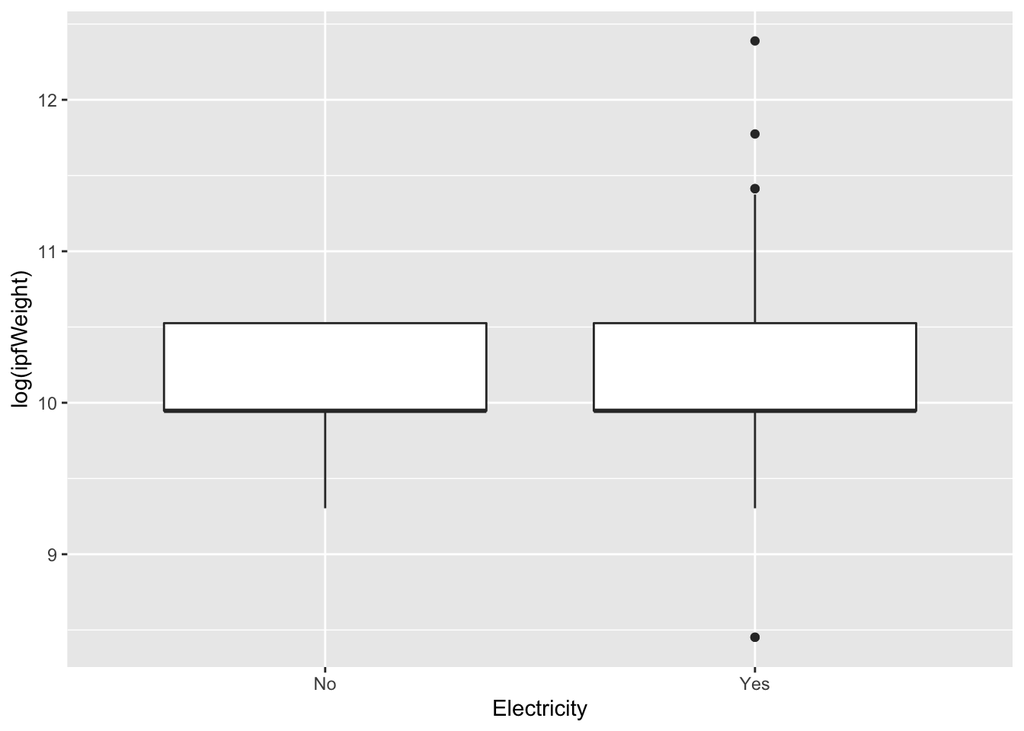

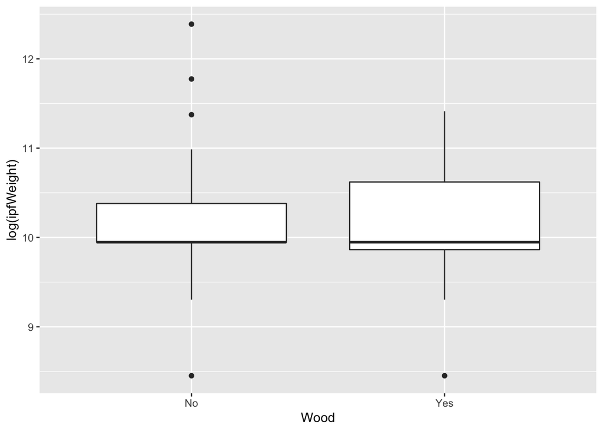

# Runtime

Analysis completed in 108.22 seconds ( 1.8 minutes) using knitr in [RStudio](http://www.rstudio.com) with R version 3.5.2 (2018-12-20) running on x86_64-apple-darwin15.6.0.

# 7 R environment

## 7.1 R packages used

- base R (R Core Team 2016)
- bookdown (Xie 2016a)
- data.table (Dowle et al. 2015)
- ggplot2 (Wickham 2009)
- kableExtra (Zhu 2018)
- knitr (Xie 2016b)
- lubridate (Grolemund and Wickham 2011)
- rmarkdown (Allaire et al. 2018)

# References

Allaire, JJ, Yihui Xie, Jonathan McPherson, Javier Luraschi, Kevin Ushey, Aron Atkins, Hadley Wickham, Joe Cheng, and Winston Chang. 2018. *Rmarkdown: Dynamic Documents for R*. https://CRAN.R-project.org/package=rmarkdown.

Anderson, Ben. 2012. “Estimating Small Area Income Deprivation: An Iterative Proportional Fitting Approach.” In *Spatial Microsimulation: A Reference Guide for Users*, edited by Kimberley Edwards and R Tanton. London: Springer.

———. 2019. “Small Area Temporal Household Electricity Demand Microsimulation Models for New Zealand: Why, How and How Far Have We Got?” In. Christchurch, Aotearoa New Zealand.

Anderson, Ben, and David Eyers. 2018. *GREENGridData: Processing Nz Green Grid Project Data to Create a ’Safe’ Version for Data Archiving and Re-Use*. https://github.com/CfSOtago/GREENGridData.

Anderson, Ben, Tom Rushby, Abubakr Bahaj, and Patrick James. 2020. “Ensuring Statistics Have Power: Guidance for Designing, Reporting and Acting on Electricity Demand Reduction and Behaviour Change Programs.” *Energy Research & Social Science* 59 (January): 101260. https://doi.org/10.1016/j.erss.2019.101260.

Battaglia, Michael P., Don A. Dillman, Martin R. Frankel, Rachel Harter, Trent D. Buskirk, Cameron B. McPhee, Jill M. DeMatteis, and Tracey Yancey. 2016. “Sampling, Data Collection, and Weighting Procedures for Address-Based Sample Surveys.” *Journal of Survey Statistics and Methodology* 4 (4): 476–500.

Beaujouan, Éva, James J. Brown, and Máire Ní Bhrolcháin. 2011. “Reweighting the General Household Survey 1979–2007.” *Population Trends* 145 (1): 119–45.

Birkin, M, and M Clarke. 2011. “Spatial Microsimulation Models: A Review and a Glimpse into the Future.” In *Population Dynamics and Projection Methods*, edited by J Stillwell and M Clarke. London: Springer.

Casati, Daniele, Kirill Müller, Pieter J. Fourie, Alexander Erath, and Kay W. Axhausen. 2015. “Synthetic Population Generation by Combining a Hierarchical, Simulation-Based Approach with Reweighting by Generalized Raking.” *Transportation Research Record* 2493 (1): 107–16.

Dortans, Carsten. 2019. “Estimating the Technical Potential for Residential Household Appliances to Reduce Daily Peak Electricity Demand in New Zealand.” Master’s thesis, University of Otago: Dunedin: Centre for Sustainability.

Dowle, M, A Srinivasan, T Short, S Lianoglou with contributions from R Saporta, and E Antonyan. 2015. *Data.table: Extension of Data.frame*. https://CRAN.R-project.org/package=data.table.

Electricity Authority/Te Mana Hiko. 2018. “Electricity in New Zealand 2018.” Annual Report. Electricity Authority. https://www.ea.govt.nz/about-us/media-and-publications/electricity-new-zealand/.

Ford, Rebecca, Sara Walton, Janet Stephenson, David Rees, Michelle Scott, Geoff King, John Williams, and Ben Wooliscroft. 2017. “Emerging Energy Transitions: PV Uptake Beyond Subsidies.” *Technological Forecasting and Social Change* 117: 138–50.

Giraldo Ocampo, Diana. 2015. “Developing an Energy-Related Time-Use Diary for Gaining Insights into New Zealand Households’ Electricity Consumption.” Master’s thesis, Centre for Sustainability: University of Otago. http://hdl.handle.net/10523/5957.

Grolemund, Garrett, and Hadley Wickham. 2011. “Dates and Times Made Easy with lubridate.” *Journal of Statistical Software* 40 (3): 1–25. http://www.jstatsoft.org/v40/i03/.

Huebner, Gesche M., Ian Hamilton, Zaid Chalabi, David Shipworth, and Tadj Oreszczyn. 2016. “Explaining Domestic Energy Consumption - the Comparative Contribution of Building Factors, Socio-Demographics, Behaviours and Attitudes.” *Applied Energy* 159 (September): 692–702. https://doi.org/10.1016/j.apenergy.2016.04.075.

Jack, M. W., K. Suomalainen, J. J. W. Dew, and D. Eyers. 2018. “A Minimal Simulation of the Electricity Demand of a Domestic Hot Water Cylinder for Smart Control.” *Applied Energy* 211: 104–12. https://www.sciencedirect.com/science/article/pii/S0306261917316197.

McKenna, Eoghan, Sarah Higginson, Philipp Grunewald, and Sarah J. Darby. 2017. “Simulating Residential Demand Response: Improving Socio-Technical Assumptions in Activity-Based Models of Energy Demand.” *Energy Efficiency*, May, 1–15. https://doi.org/10.1007/s12053-017-9525-4.

McKenna, Eoghan, and Murray Thomson. 2016. “High-Resolution Stochastic Integrated Thermal–Electrical Domestic Demand Model.” *Applied Energy* 165 (March): 445–61. https://doi.org/10.1016/j.apenergy.2015.12.089.

R Core Team. 2016. *R: A Language and Environment for Statistical Computing*. Vienna, Austria: R Foundation for Statistical Computing. https://www.R-project.org/.

Simpson, L, and M Tranmer. 2005. “Combining Sample and Census Data in Small Area Estimates: Iterative Proportional Fitting with Standard Software.” *The Professional Geographer* 57 (2): 222–34.

Sovacool, Benjamin K., Jonn Axsen, and Steve Sorrell. 2018. “Promoting Novelty, Rigor, and Style in Energy Social Science: Towards Codes of Practice for Appropriate Methods and Research Design.” *Energy Research & Social Science*, October. https://doi.org/10.1016/j.erss.2018.07.007.

Stephenson, Janet, Rebecca Ford, Nirmal-Kumar Nair, Neville Watson, Alan Wood, and Allan Miller. 2017. “Smart Grid Research in New Zealand–A Review from the GREEN Grid Research Programme.” *Renewable and Sustainable Energy Reviews* 82 (1): 1636–45. https://doi.org/10.1016/j.rser.2017.07.010.

Suomalainen, Kiti, David Eyers, Rebecca Ford, Janet Stephenson, Ben Anderson, and Michael Jack. 2019. “Detailed Comparison of Energy-Related Time-Use Diaries and Monitored Residential Electricity Demand.” *Energy and Buildings* 183: 418–27. https://doi.org/10.1016/j.enbuild.2018.11.002.

Tanton, Robert. 2018. “Spatial Microsimulation: Developments and Potential Future Directions.” *International Journal of Microsimulation* 11 (1): 143–61.

Vicki White, and Mark Jones. 2017. “Warm, Dry, Healthy? Insights from the 2015 House Condition Survey on Insulation, Ventilation, Heating and Mould in New Zealand Houses.” SR 372. Porirua, New Zealand: BRANZ Ltd.

Whitworth, Adam, E. Carter, Dimitris Ballas, and G. Moon. 2017. “Estimating Uncertainty in Spatial Microsimulation Approaches to Small Area Estimation: A New Approach to Solving an Old Problem.” *Computers, Environment and Urban Systems* 63: 50–57.

Wickham, Hadley. 2009. *Ggplot2: Elegant Graphics for Data Analysis*. Springer-Verlag New York. http://ggplot2.org.

Wong, DWS. 1992. “The Reliability of Using the Iterative Proportional Fitting Procedure∗.” *The Professional Geographer*. http://www.tandfonline.com/doi/abs/10.1111/j.0033-0124.1992.00340.x.

Wooliscroft, B. 2015. “National Household Survey of Energy and Transportation: Energy Cultures Two.” Centre for Sustainability: University of Otago. http://hdl.handle.net/10523/5634.

Xie, Yihui. 2016a. *Bookdown: Authoring Books and Technical Documents with R Markdown*. Boca Raton, Florida: Chapman; Hall/CRC. https://github.com/rstudio/bookdown.

———. 2016b. *Knitr: A General-Purpose Package for Dynamic Report Generation in R*. https://CRAN.R-project.org/package=knitr.

Zhu, Hao. 2018. *KableExtra: Construct Complex Table with ’Kable’ and Pipe Syntax*. https://CRAN.R-project.org/package=kableExtra.